# HOMEWORK 2

Duygu Kaya - IE582 - Fall 2020

### Dimensionality reduction for time series data

The aim is to obtain three dimensional data to one dimensional data with univariate time series by using dimension reduction.To achieve this, three-axis accelerometer data from eight users is collected to characterize eight gesture patterns. The data, uWaveGestureLibrary, consists over 4000 instances each of which has the accelerometer readings in three dimensions( x, y and z).There are separate files for each axis.

```r
# Import library
library(stats)
library(base)
library(ggplot2)
library(dplyr)
library(plot3D)
library(reshape)
library(tidyr)
```

```r
# Read datasets
x_train <- read.table("C:\\Users\\kayad\\Desktop\\uWaveGestureLibrary_X_TRAIN")
y_train <- read.table("C:\\Users\\kayad\\Desktop\\uWaveGestureLibrary_Y_TRAIN")
z_train <- read.table("C:\\Users\\kayad\\Desktop\\uWaveGestureLibrary_Z_TRAIN")

# change the name of first column in dataframes
names(x_train)[1] <- "class"
names(y_train)[1] <- "class"
names(z_train)[1] <- "class"
```

```r
# Velocities from accelaration
velocity_x_train = x_train[2:316]
velocity_x_train = t(apply(velocity_x_train,1,cumsum))
velocity_x_train = cbind(x_train$class,velocity_x_train)

velocity_y_train = y_train[2:316]
velocity_y_train = t(apply(velocity_y_train,1,cumsum))
velocity_y_train = cbind(y_train$class,velocity_y_train)


velocity_z_train = z_train[2:316]
velocity_z_train = t(apply(velocity_z_train,1,cumsum))
velocity_z_train = cbind(z_train$class,velocity_z_train)

# Positions from velocity
position_x_train = velocity_x_train[,2:316]
position_x_train = t(apply(position_x_train,1,cumsum))
position_x_train = cbind(x_train$class,position_x_train)

position_y_train = velocity_y_train[,2:316]
position_y_train = t(apply(position_y_train,1,cumsum))
position_y_train = cbind(y_train$class,position_y_train)

position_z_train = velocity_z_train[,2:316]
position_z_train = t(apply(position_z_train,1,cumsum))
position_z_train = cbind(z_train$class,position_z_train)
```

### Task A

In this task, position variables that are obtained by cumulative sum of velocities are visualized one instance (all axes) from each class to become familiar with the shape of the gestures in the figure 1.

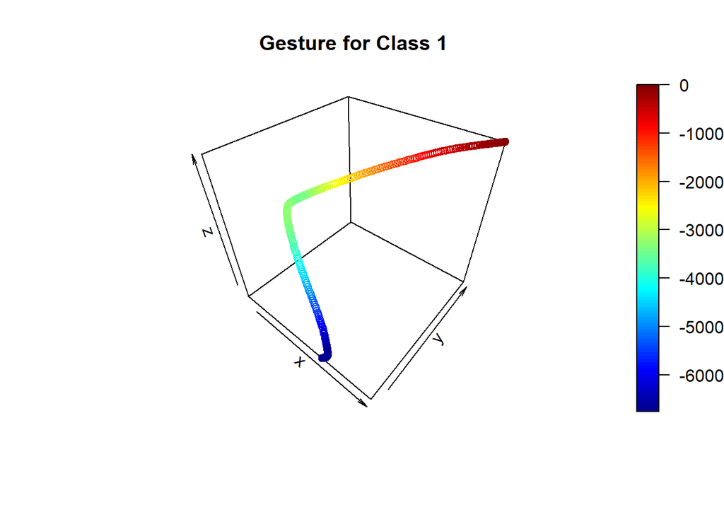

```r
# Plots for each class

# class 1
x_class1 = position_x_train[position_x_train[,1] == 1,]
y_class1 = position_y_train[position_y_train[,1] == 1,]
z_class1 = position_z_train[position_z_train[,1] == 1,]
scatter3D(x_class1[1,],y_class1[1,],z_class1[1,], main = paste("Gesture for Class 1"))
```

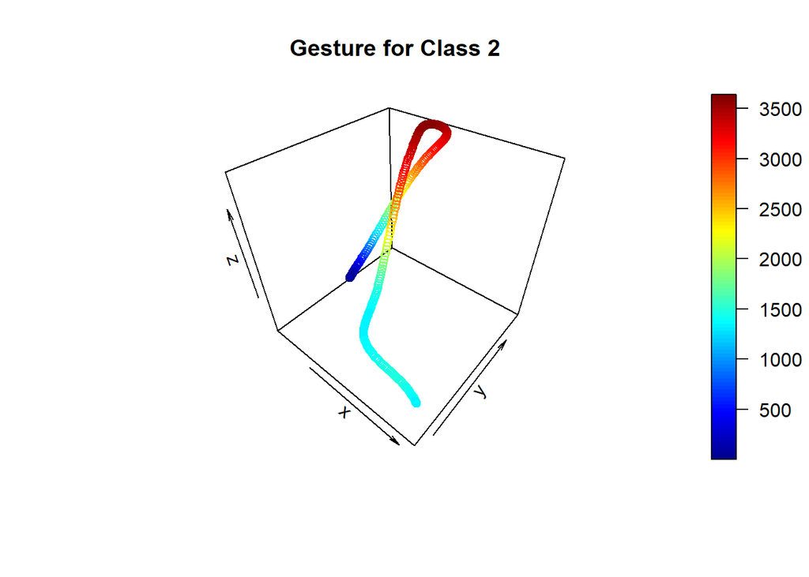

```r
# class 2
x_class2 = position_x_train[position_x_train[,1] == 2,]
y_class2 = position_y_train[position_y_train[,1] == 2,]
z_class2 = position_z_train[position_z_train[,1] == 2,]
scatter3D(x_class2[1,],y_class2[1,],z_class2[1,], main = paste("Gesture for Class 2"))
```

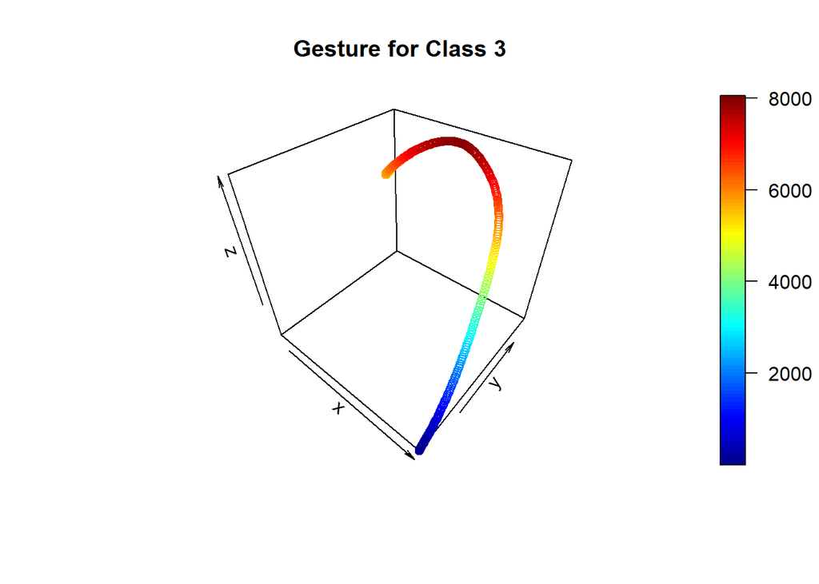

```r
# Class 3
x_class3 = position_x_train[position_x_train[,1] == 3,]
y_class3 = position_y_train[position_y_train[,1] == 3,]
z_class3 = position_z_train[position_z_train[,1] == 3,]
scatter3D(x_class3[1,],y_class3[1,],z_class3[1,], main = paste("Gesture for Class 3"))
```

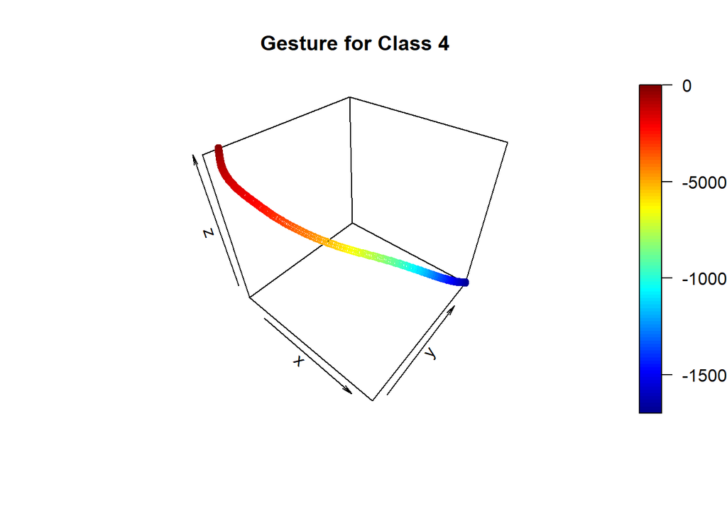

```r
# Class 4
x_class4 = position_x_train[position_x_train[,1] == 4,]
y_class4 = position_y_train[position_y_train[,1] == 4,]
z_class4 = position_z_train[position_z_train[,1] == 4,]
scatter3D(x_class4[1,],y_class4[1,],z_class4[1,], main = paste("Gesture for Class 4"))
```

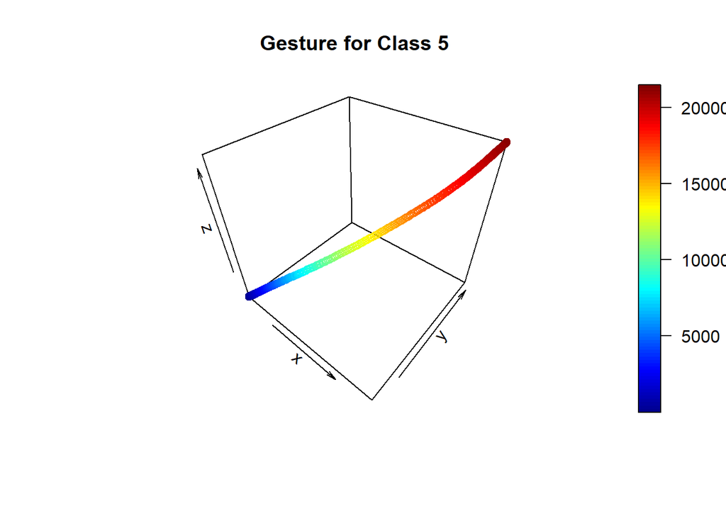

```r
# Class 5
x_class5 = position_x_train[position_x_train[,1] == 5,]
y_class5 = position_y_train[position_y_train[,1] == 5,]
z_class5 = position_z_train[position_z_train[,1] == 5,]
scatter3D(x_class5[1,],y_class5[1,],z_class5[1,], main = paste("Gesture for Class 5"))
```

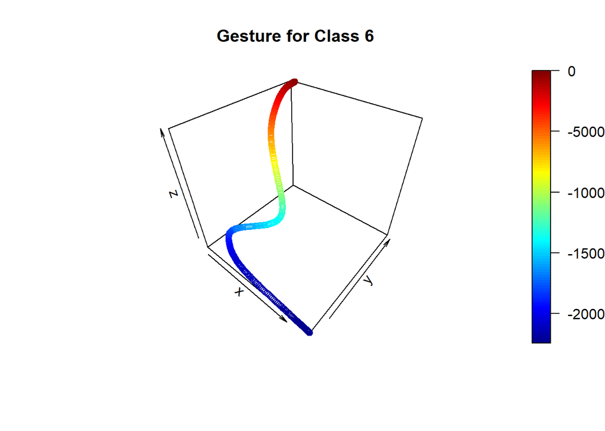

```r
# Class 6
x_class6 = position_x_train[position_x_train[,1] == 6,]
y_class6 = position_y_train[position_y_train[,1] == 6,]
z_class6 = position_z_train[position_z_train[,1] == 6,]
scatter3D(x_class6[1,],y_class6[1,],z_class6[1,], main = paste("Gesture for Class 6"))
```

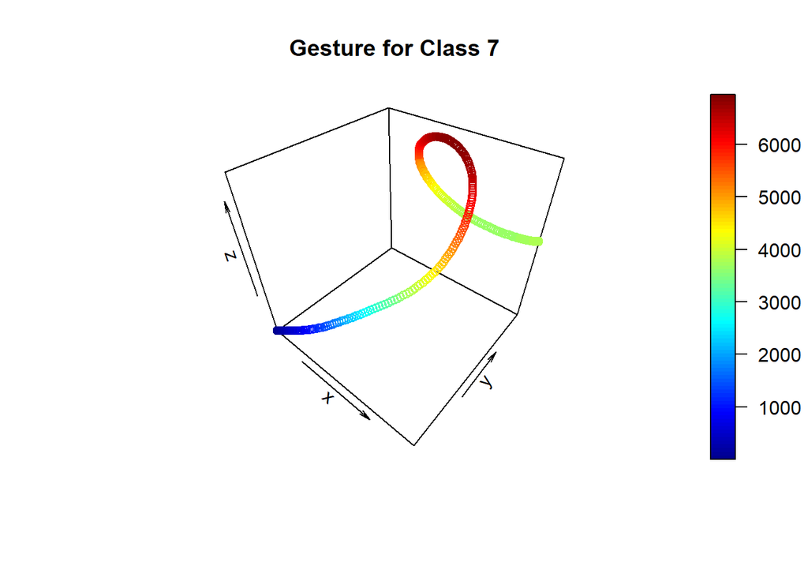

```r
# Class 7
x_class7 = position_x_train[position_x_train[,1] == 7,]
y_class7 = position_y_train[position_y_train[,1] == 7,]
z_class7 = position_z_train[position_z_train[,1] == 7,]
scatter3D(x_class7[1,],y_class7[1,],z_class7[1,], main = paste("Gesture for Class 7"))
```

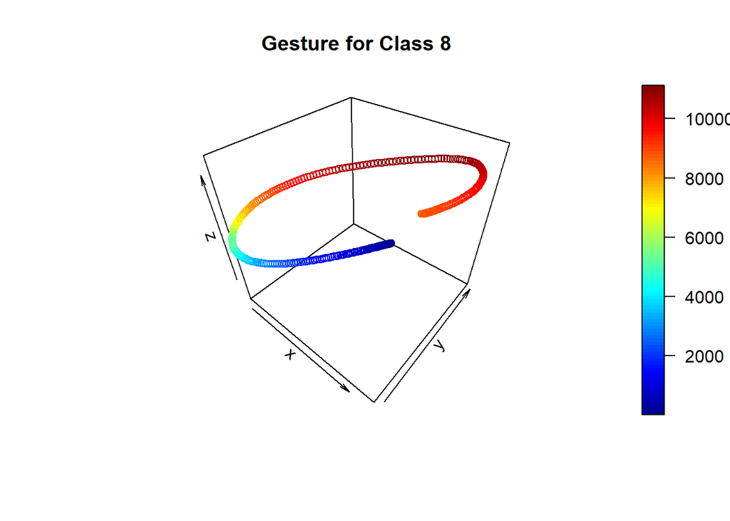

```r
# Class 8
x_class8 = position_x_train[position_x_train[,1] == 8,]
y_class8 = position_y_train[position_y_train[,1] == 8,]
z_class8 = position_z_train[position_z_train[,1] == 8,]
scatter3D(x_class8[1,],y_class8[1,],z_class8[1,], main = paste("Gesture for Class 8"))
```

### Task B

The aim of this task is to reduce this multivariate time series (x,y,z) to a univariate one with a dimensionality reduction approach.To achieve this task, x,y and z variables are combined and converted wide format to long format.Then, PCA is applied and first component is used to dimension reduction.Then, random time series are selected from each class and visualized the reduced dimensions as time series in a single plot to see if classes can be separated in the reduced dimensions.

```r
x_train$time_series_id <- c(1:896)
y_train$time_series_id <- c(1:896)
z_train$time_Series_id <- c(1:896)

x_train_long = pivot_longer(x_train, cols=2:316, names_to = "time_index", values_to = "X")
y_train_long = pivot_longer(y_train, cols=2:316, names_to = "time_index", values_to = "Y")
z_train_long = pivot_longer(z_train, cols=2:316, names_to = "time_index", values_to = "Z")

data = cbind(x_train_long,y_train_long[,4],z_train_long[,4])


# Apply dimension reduction by using PCA

data_reduced = data[4:6]
data_pca <- princomp(data_reduced , cor = TRUE)
summary(data_pca,loadings = TRUE)
```

```
## Importance of components:
##                          Comp.1    Comp.2    Comp.3
## Standard deviation     1.213171 1.0198583 0.6986445
## Proportion of Variance 0.490595 0.3467037 0.1627014
## Cumulative Proportion  0.490595 0.8372986 1.0000000
##
## Loadings:
##   Comp.1 Comp.2 Comp.3
## X  0.427  0.776  0.464
## Y  0.721        -0.692
## Z  0.546 -0.630  0.553
```

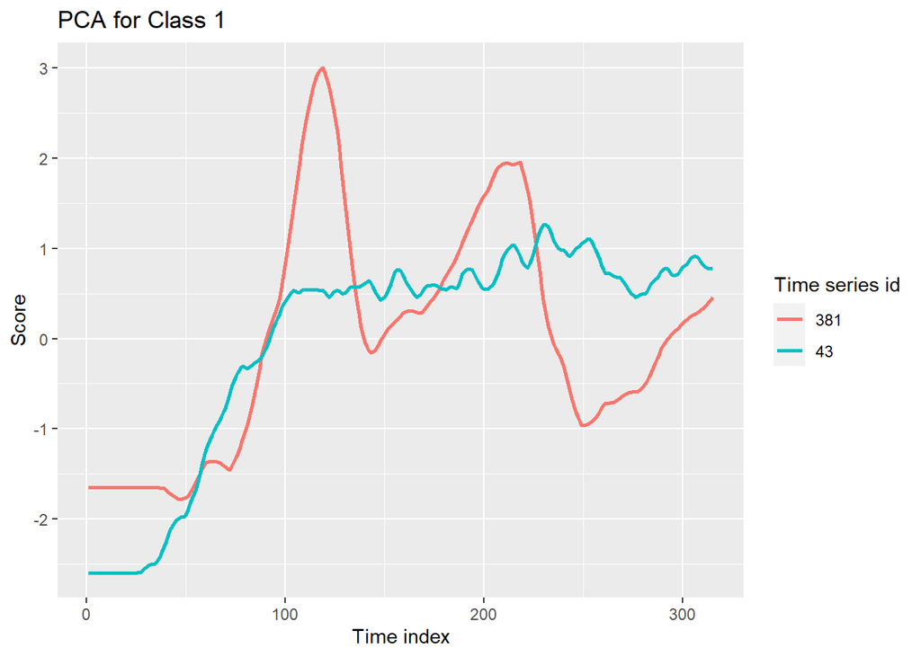

```r
# Plot random variables of Class 1 from reduced data
data_pca_reduced = data_pca$scores
data = cbind(data,data_pca_reduced[,1])
names(data)[7] <- "xyz"

class1_pca = data[data[,1] == 1,]
obs381 = class1_pca[class1_pca[,2] == 381,]
obs43  = class1_pca[class1_pca[,2] == 43,]
time = c(1:315)
class1_pca = cbind(obs381, obs43[,7],time)
names(class1_pca)[8] <- "xyz2"

ggplot()+
  geom_line(data=class1_pca,aes(y=xyz,x= time,colour="darkred"),size=1 )+
  geom_line(data=class1_pca,aes(y=xyz2,x= time,colour="steelblue"),size=1) +
  scale_color_discrete(name = "Time series id", labels = c("381", "43"))+xlab("Time index")+
  ylab("Score")+ggtitle("PCA for Class 1")
```

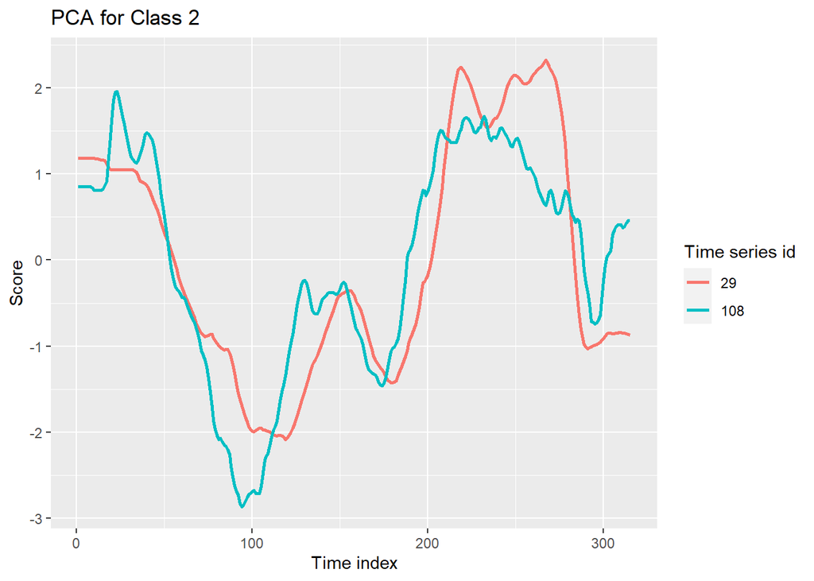

```r
# Plot random variables of Class 2 from reduced data
class2_pca = data[data[,1] == 2,]
obs29 = class2_pca[class2_pca[,2] == 29,]
obs108  = class2_pca[class2_pca[,2] == 108,]
time = c(1:315)
class2_pca = cbind(obs29, obs108[,7],time)
names(class2_pca)[8] <- "xyz2"

ggplot()+
  geom_line(data=class2_pca,aes(y=xyz,x= time,colour="darkred"),size=1 )+
  geom_line(data=class2_pca,aes(y=xyz2,x= time,colour="steelblue"),size=1) +
  scale_color_discrete(name = "Time series id", labels = c("29", "108"))+xlab("Time index")+
  ylab("Score")+ggtitle("PCA for Class 2")
```

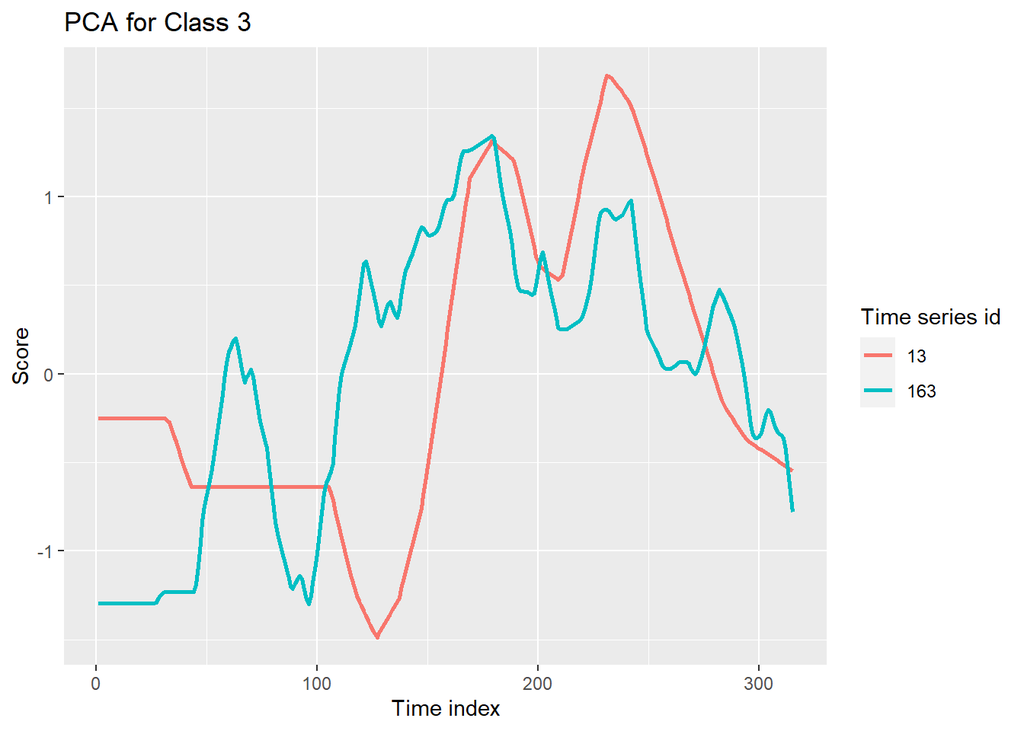

```r
# Plot random variables of Class 3 from reduced data
class3_pca = data[data[,1] == 3,]
obs13 = class3_pca[class3_pca[,2] == 13,]
obs163 = class3_pca[class3_pca[,2] == 163,]
time = c(1:315)
class3_pca = cbind(obs13, obs163[,7],time)
names(class3_pca)[8] <- "xyz2"

ggplot()+
  geom_line(data=class3_pca,aes(y=xyz,x= time,colour="darkred"),size=1 )+
  geom_line(data=class3_pca,aes(y=xyz2,x= time,colour="steelblue"),size=1) +
  scale_color_discrete(name = "Time series id", labels = c("13", "163"))+xlab("Time index")+
  ylab("Score")+ggtitle("PCA for Class 3")
```

[figure not shown]

```r
# Plot random variables of Class 4 from reduced data
class4_pca = data[data[,1] == 4,]
obs141 = class4_pca[class4_pca[,2] == 141,]
obs328 = class4_pca[class4_pca[,2] == 328,]
time = c(1:315)
class4_pca = cbind(obs141, obs328[,7],time)
names(class4_pca)[8] <- "xyz2"

ggplot()+
  geom_line(data=class4_pca,aes(y=xyz,x= time,colour="darkred"),size=1 )+
  geom_line(data=class4_pca,aes(y=xyz2,x= time,colour="steelblue"),size=1) +
  scale_color_discrete(name = "Time series id", labels = c("141", "358"))+xlab("Time index")+
  ylab("Score")+ggtitle("PCA for Class 4")
```

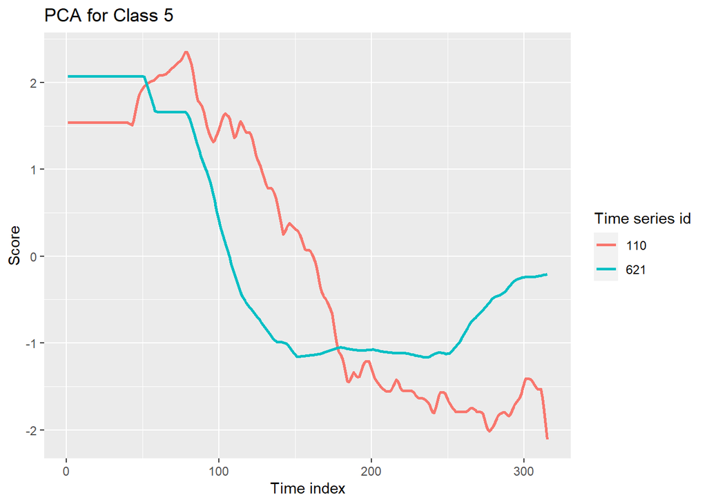

```r
# Plot random variables of Class 5 from reduced data
class5_pca = data[data[,1] == 5,]
obs110 = class5_pca[class5_pca[,2] == 110,]
obs621 = class5_pca[class5_pca[,2] == 621,]
time = c(1:315)
class5_pca = cbind(obs110, obs621[,7],time)
names(class5_pca)[8] <- "xyz2"

ggplot()+
  geom_line(data=class5_pca,aes(y=xyz,x= time,colour="darkred"),size=1 )+
  geom_line(data=class5_pca,aes(y=xyz2,x= time,colour="steelblue"),size=1) +
  scale_color_discrete(name = "Time series id", labels = c("110", "621"))+xlab("Time index")+
  ylab("Score")+ggtitle("PCA for Class 5")
```

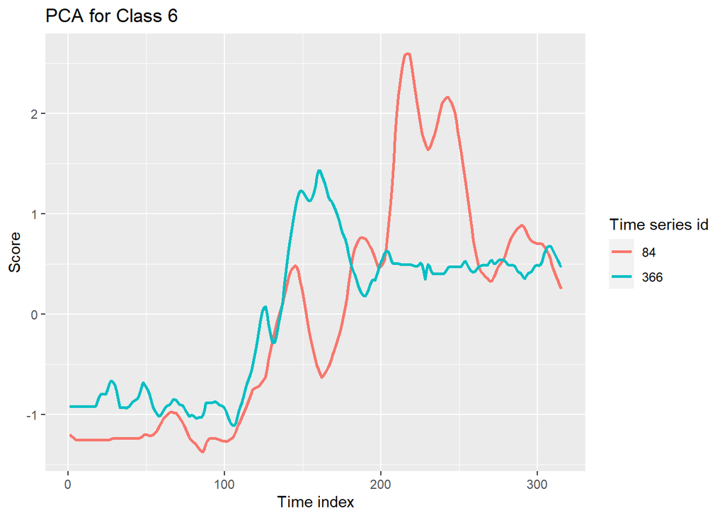

```r
# Plot random variables of Class 6 from reduced data
class6_pca = data[data[,1] == 6,]
obs84 = class6_pca[class6_pca[,2] == 84,]
obs366 = class6_pca[class6_pca[,2] == 366,]
time = c(1:315)
class6_pca = cbind(obs84, obs366[,7],time)
names(class6_pca)[8] <- "xyz2"

ggplot()+
  geom_line(data=class6_pca,aes(y=xyz,x= time,colour="darkred"),size=1 )+
  geom_line(data=class6_pca,aes(y=xyz2,x= time,colour="steelblue"),size=1) +
  scale_color_discrete(name = "Time series id", labels = c("84", "366"))+xlab("Time index")+
  ylab("Score")+ggtitle("PCA for Class 6")
```

[figure not shown]

```r
# Plot random variables of Class 7 from reduced data
class7_pca = data[data[,1] == 7,]
obs32 = class7_pca[class7_pca[,2] == 32,]
obs570 = class7_pca[class7_pca[,2] == 570,]
time = c(1:315)
class7_pca = cbind(obs32, obs570[,7],time)
names(class7_pca)[8] <- "xyz2"

ggplot()+
  geom_line(data=class6_pca,aes(y=xyz,x= time,colour="darkred"),size=1 )+
  geom_line(data=class6_pca,aes(y=xyz2,x= time,colour="steelblue"),size=1) +
  scale_color_discrete(name = "Time series id", labels = c("32", "570"))+xlab("Time index")+
  ylab("Score")+ggtitle("PCA for Class 7")
```

[figure not shown]

```r
# Plot random variables of Class 8 from reduced data
class8_pca = data[data[,1] == 8,]
obs168 = class8_pca[class8_pca[,2] == 168,]
obs715 = class8_pca[class8_pca[,2] == 715,]
time = c(1:315)
class8_pca = cbind(obs168, obs715[,7],time)
names(class8_pca)[8] <- "xyz2"

ggplot()+
  geom_line(data=class6_pca,aes(y=xyz,x= time,colour="darkred"),size=1 )+
  geom_line(data=class6_pca,aes(y=xyz2,x= time,colour="steelblue"),size=1) +
  scale_color_discrete(name = "Time series id", labels = c("168", "715"))+xlab("Time index")+
  ylab("Score")+ggtitle("PCA for Class 8")
```

The proportion of variance for comp1 is 0.49 , 0.34 for comp2 and 0.16 for comp3 are found from PCA results.The comp1 is used for dimension reduction due to the importance. The plots from each class relatively similar but some of them have different patterns.It is not unexpected since there are some lost variance.

### Task C

In this task,data is filtered for each class and PCA is performed to compare the first principal component when PCA is applied on the data from each gesture.

```r
# PCA for Class 1
class1 = data[data[,1] == 1,]
a = class1[4:6]
pca.class1 <- princomp(a , cor = TRUE)
summary(pca.class1, loadings = TRUE)
```

```
## Importance of components:
##                           Comp.1    Comp.2    Comp.3
## Standard deviation     1.1779640 0.9845807 0.8018738
## Proportion of Variance 0.4625331 0.3231331 0.2143339
## Cumulative Proportion  0.4625331 0.7856661 1.0000000
##
## Loadings:
##   Comp.1 Comp.2 Comp.3
## X  0.357  0.896  0.263
## Y  0.691        -0.720
## Z  0.629 -0.439  0.642
```

```r
# PCA for Class 2
class2 = data[data[,1] == 2,]
b = class2[4:6]
pca.class2 <- princomp(b , cor = TRUE)
summary(pca.class2,loadings = TRUE)
```

```
## Importance of components:
##                           Comp.1    Comp.2    Comp.3
## Standard deviation     1.2400176 0.9682706 0.7244366
## Proportion of Variance 0.5125479 0.3125160 0.1749361
## Cumulative Proportion  0.5125479 0.8250639 1.0000000
##
## Loadings:
##   Comp.1 Comp.2 Comp.3
## X  0.455  0.801  0.388
## Y  0.685        -0.728
## Z  0.569 -0.597  0.565
```

```r
# PCA for Class 3
class3 = data[data[,1] == 3,]
c = class3[4:6]
pca.class3 <- princomp(c ,cor = TRUE)
summary(pca.class3, loadings = TRUE)
```

```
## Importance of components:
##                          Comp.1    Comp.2    Comp.3
## Standard deviation     1.273669 0.9475424 0.6927707
## Proportion of Variance 0.540744 0.2992789 0.1599771
## Cumulative Proportion  0.540744 0.8400229 1.0000000
##
## Loadings:
##   Comp.1 Comp.2 Comp.3
## X  0.675         0.738
## Y  0.531  0.689 -0.494
## Z -0.513  0.725  0.460
```

```r
# PCA for Class 4
class4 = data[data[,1] == 4,]
d = class4[4:6]
pca.class4 <- princomp(d , cor = TRUE)
summary(pca.class4, loadings = TRUE)
```

```
## Importance of components:
##                           Comp.1    Comp.2    Comp.3
## Standard deviation     1.2846735 0.9605566 0.6534102
## Proportion of Variance 0.5501287 0.3075563 0.1423150
## Cumulative Proportion  0.5501287 0.8576850 1.0000000
##
## Loadings:
##   Comp.1 Comp.2 Comp.3
## X  0.681  0.113  0.724
## Y  0.634  0.404 -0.659
## Z -0.367  0.908  0.204
```

```r
# PCA for Class 5
class5 = data[data[,1] == 5,]
e = class5[4:6]
pca.class5 <- princomp(e , cor = TRUE)
summary(pca.class5, loadings = TRUE)
```

```
## Importance of components:
##                           Comp.1    Comp.2     Comp.3
## Standard deviation     1.3934383 0.9076507 0.48425204
## Proportion of Variance 0.6472234 0.2746099 0.07816668
## Cumulative Proportion  0.6472234 0.9218333 1.00000000
##
## Loadings:
##   Comp.1 Comp.2 Comp.3
## X  0.399  0.915
## Y  0.643 -0.321  0.696
## Z  0.654 -0.243 -0.716
```

```r
# PCA for Class 6
class6 = data[data[,1] == 6,]
f = class6[4:6]
pca.class6 <- princomp(f , cor = TRUE)
summary(pca.class6, loadings = TRUE)
```

```
## Importance of components:
##                           Comp.1    Comp.2     Comp.3
## Standard deviation     1.3097601 0.9941695 0.54420161
## Proportion of Variance 0.5718239 0.3294577 0.09871846
## Cumulative Proportion  0.5718239 0.9012815 1.00000000
##
## Loadings:
##   Comp.1 Comp.2 Comp.3
## X  0.206  0.964  0.167
## Y -0.680  0.264 -0.684
## Z -0.704         0.710
```

```r
# PCA for Class 7
class7 = data[data[,1] == 7,]
g = class7[4:6]
pca.class7 <- princomp(g , cor = TRUE)
summary(pca.class7, loadings = TRUE)
```

```
## Importance of components:
##                           Comp.1    Comp.2    Comp.3
## Standard deviation     1.2480424 1.0144419 0.6428823
## Proportion of Variance 0.5192033 0.3430308 0.1377659
## Cumulative Proportion  0.5192033 0.8622341 1.0000000
##
## Loadings:
##   Comp.1 Comp.2 Comp.3
## X  0.229  0.925  0.304
## Y  0.715        -0.697
## Z  0.661 -0.377  0.649
```

```r
# PCA for Class 8
class8 = data[data[,1] == 8,]
h = class8[4:6]
pca.class8 <- princomp(h , cor = TRUE)
summary(pca.class8, loadings = TRUE)
```

```
## Importance of components:
##                           Comp.1    Comp.2     Comp.3
## Standard deviation     1.3565694 0.9675745 0.47277805
## Proportion of Variance 0.6134269 0.3120668 0.07450636
## Cumulative Proportion  0.6134269 0.9254936 1.00000000
##
## Loadings:
##   Comp.1 Comp.2 Comp.3
## X  0.574  0.584  0.574
## Y  0.693        -0.721
## Z  0.436 -0.811  0.389
```

### Task D

The aim is is to visualize the time series in reduced dimensions for classification purposes.Multidimensional scaling is applied to distance matrix to represent each time series on a 2-dimensional feature space.

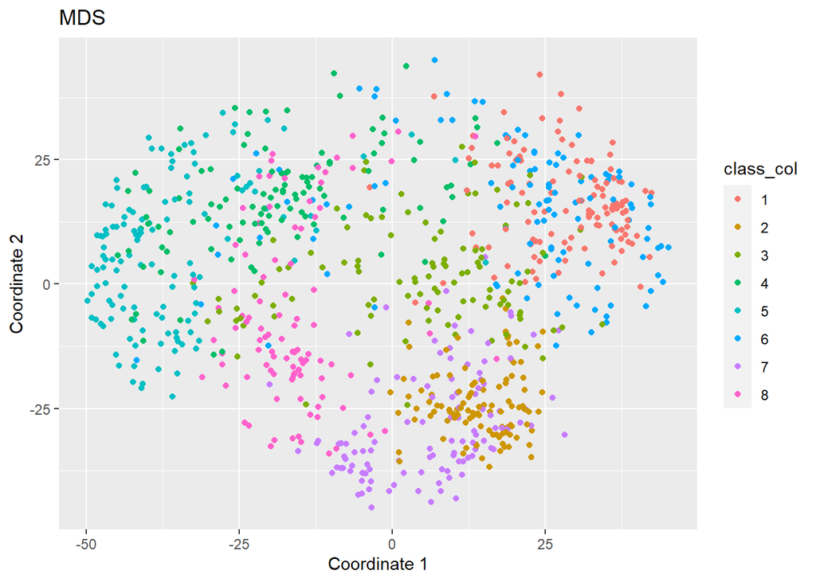

```r
distance_x_train = dist(x_train[, 2:316], method = 'euclidean')
distance_y_train = dist(y_train[, 2:316], method = 'euclidean')
distance_z_train = dist(z_train[, 2:316], method = 'euclidean')
distance = distance_x_train + distance_y_train + distance_z_train
fit <- cmdscale(distance,eig = TRUE, k=2)

# plot for MDS

k <- fit$points[,1]
m <- fit$points[,2]

mds_data = cbind(x_train[,1],k,m)
mds_data = as.data.frame(mds_data)
names(mds_data)[1] <-"class"
class_col = as.factor(mds_data$class)

ggplot(data = mds_data)+geom_point(mapping = aes(x = k,y = m,colour=class_col))+
  xlab("Coordinate 1")+ylab("Coordinate 2")+ ggtitle("MDS")+theme(legend.position = "right")
```